# Practical Machine Learning Project

David Bataller Sendra

12 de mayo de 2018

```r
library (caret)
library (rpart)
library (rattle)
```

```
## Versión 5.1.0 Copyright (c) 2006-2017 Togaware Pty Ltd.
## Escriba 'rattle()' para agitar, sacudir y  rotar sus datos.
```

```r
library (randomForest)
```

## Background

Using devices such as Jawbone Up, Nike FuelBand, and Fitbit it is now possible to collect a large amount of data about personal activity relatively inexpensively. These type of devices are part of the quantified self movement – a group of enthusiasts who take measurements about themselves regularly to improve their health, to find patterns in their behavior, or because they are tech geeks. One thing that people regularly do is quantify how much of a particular activity they do, but they rarely quantify how well they do it.

The goal of this project is to use data from accelerometers on the belt, forearm, arm, and dumbbell of 6 young health participants. They were asked to perform one set of 10 repetitions of the Unilateral Dumbbell Biceps Curl in five different ways: exactly according to the specification (Class A), throwing the elbows to the front (Class B), lifting the dumbbell only halfway (Class C), lowering the dumbbell only halfway (Class D) and throwing the hips to the front (Class E). More information is available from the website here: http://groupware.les.inf.puc-rio.br/bar (see the section on the WLE Dataset).

## Getting and loading the data

We first download both training and testing datasets:

```r
set.seed(138)

train_Url <- "http://d396qusza40orc.cloudfront.net/predmachlearn/pml-training.csv"
test_Url <- "http://d396qusza40orc.cloudfront.net/predmachlearn/pml-testing.csv"

training <- read.csv(url(train_Url), na.strings = c("NA","#DIV/0!",""))
testing <- read.csv(url(test_Url), na.strings = c("NA","#DIV/0!",""))

dim (training)
```

```
## [1] 19622   160
```

```r
dim (testing)
```

```
## [1]  20 160
```

We can see that the training dataset has 19622 observations and 160 variables, and the testing dataset has 20 observations and the same 160 variables. The goal is to predict the outcome of the variable **classe** in the training set.

## Cleanning the data

In order to clean the data, we remove the columns which have missing values:

```r
training <- training[, colSums (is.na (training)) == 0 & colSums (is.na (testing)) == 0]
```

Then, we remove the first two columns, which are an identifier of the observation and the user name:

```r
training <- training[, -c(1,2)]
```

And finally, we remove the columns with very little variance:

```r
nzv <- nearZeroVar(training)
training <- training[, -nzv]
```

Now we obtain the same columns in the testing dataset than in the training dataset except the last one, which is the target, and make sure the class of all variables are the same as in training data set:

```r
testing <- testing[, names(training[, -length (training)])]
testing <- rbind(training[1, -length (training)] , testing)
testing <- testing[-1, ]
```

## Spliting training dataset into two sets

In order to validate the models we are going to test, we split the training data set into the real training set, and the validation set:

```r
train_index <- createDataPartition(training$classe, p = 0.7, list = FALSE)
training_set <- training[train_index, ]
validation_set <- training[-train_index, ]
```

## Predict with Decision Trees model

Now we try to fit a Decision Trees model:

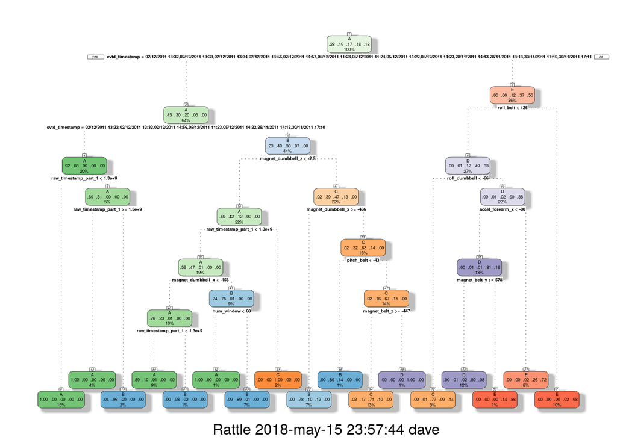

```r
DT_model <- rpart(classe ~ ., data = training_set, method="class")
fancyRpartPlot(DT_model)
```

And predict the **clase** variable with the model:

```r
DT_prediction <- predict (DT_model, validation_set, type = "class")
confusionMatrix (DT_prediction, validation_set$classe)
```

```
## Confusion Matrix and Statistics
##
##           Reference
## Prediction    A    B    C    D    E
##          A 1625   39    6    2    0
##          B   35  942   58   40    0
##          C   14  151  951  110   37
##          D    0    7    6  660   71
##          E    0    0    5  152  974
##
## Overall Statistics
##
##                Accuracy : 0.8754
##                  95% CI : (0.8667, 0.8838)
##     No Information Rate : 0.2845
##     P-Value [Acc > NIR] : < 2.2e-16
##
##                   Kappa : 0.8424
##  Mcnemar's Test P-Value : NA
##
## Statistics by Class:
##
##                      Class: A Class: B Class: C Class: D Class: E
## Sensitivity            0.9707   0.8270   0.9269   0.6846   0.9002
## Specificity            0.9888   0.9720   0.9358   0.9829   0.9673
## Pos Pred Value         0.9719   0.8763   0.7530   0.8871   0.8612
## Neg Pred Value         0.9884   0.9590   0.9838   0.9409   0.9773
## Prevalence             0.2845   0.1935   0.1743   0.1638   0.1839
## Detection Rate         0.2761   0.1601   0.1616   0.1121   0.1655
## Detection Prevalence   0.2841   0.1827   0.2146   0.1264   0.1922
## Balanced Accuracy      0.9798   0.8995   0.9313   0.8338   0.9337
```

Here we see that the accuracy of this model is 87.54%.

## Predict with Random Forest model

Now we try to fit a Random Forest model:

```r
RF_model <- randomForest (classe ~ ., data = training_set)
```

And predict the **clase** variable with the model:

```r
RF_prediction <- predict (RF_model, validation_set, type = "class")
confusionMatrix (RF_prediction, validation_set$classe)
```

```
## Confusion Matrix and Statistics
##
##           Reference
## Prediction    A    B    C    D    E
##          A 1674    2    0    0    0
##          B    0 1137    1    0    0
##          C    0    0 1023    0    0
##          D    0    0    2  962    0
##          E    0    0    0    2 1082
##
## Overall Statistics
##
##                Accuracy : 0.9988
##                  95% CI : (0.9976, 0.9995)
##     No Information Rate : 0.2845
##     P-Value [Acc > NIR] : < 2.2e-16
##
##                   Kappa : 0.9985
##  Mcnemar's Test P-Value : NA
##
## Statistics by Class:
##
##                      Class: A Class: B Class: C Class: D Class: E
## Sensitivity            1.0000   0.9982   0.9971   0.9979   1.0000
## Specificity            0.9995   0.9998   1.0000   0.9996   0.9996
## Pos Pred Value         0.9988   0.9991   1.0000   0.9979   0.9982
## Neg Pred Value         1.0000   0.9996   0.9994   0.9996   1.0000
## Prevalence             0.2845   0.1935   0.1743   0.1638   0.1839
## Detection Rate         0.2845   0.1932   0.1738   0.1635   0.1839
## Detection Prevalence   0.2848   0.1934   0.1738   0.1638   0.1842
## Balanced Accuracy      0.9998   0.9990   0.9985   0.9988   0.9998
```

This time, the accuracy is 99.88%. So the Random Forest model is better.

## Predict with testing dataset

Finally, we use the testing dataset to predict the **clase** variable with new data:

```r
predict (RF_model, testing, type = "class")
```

```
##  2  3  4  5  6  7  8  9 10 11 12 13 14 15 16 17 18 19 20 21
##  B  A  B  A  A  E  D  B  A  A  B  C  B  A  E  E  A  B  B  B
## Levels: A B C D E
```